# Warum bringen die Menschen einander um - Bayerische Staatsoper

[figure not shown]

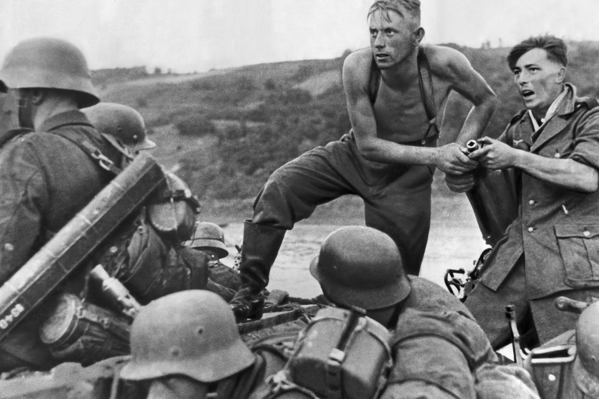

# „Warum bringen die Menschen einander um?“

Tolstoi und der Krieg

Text: Prof. Dr. Andrei Zorin

*Prof. Dr. Andrei Zorin ist Chair (Ordinarius) für Russische Literatur an der Universität von Oxford. Sein Fachgebiet ist die russische Kultur- und Literaturgeschichte im europäischen Kontext, insbesondere die des 18. und 19. Jahrhunderts. Gastprofessuren führten ihn an die Universitäten von Harvard, Stanford, New York und Michigan. Kürzlich erschien von ihm die grundlegende Biografie Leo Tolstoy. A Critical Life (London 2020). Zu seinen weiteren Veröffentlichungen zählen, neben über 150 Artikeln in Fachmagazinen, die Bücher By Fables Alone. Russian Literature and Official Ideology in Late Eighteenth – Early Nineteenth Century (Boston 2014), On the Periphery of Europe, 1762–1825. The Self-Invention of the Russian Elite (mit Аndreas Schönle, DeKalb 2018), The Emergence of a Hero. A Tale of Romantic Love in Russia around 1800 (Oxford 2023, im Druck).*

Nicht nur die vielen Verehrer von Lew Tolstoi, sondern auch die Literaturwissenschaftler haben manchmal Schwierigkeiten, seine zwei Gesichter miteinander in Einklang zu bringen: Der junge Artillerieoffizier, der am Kolonialkrieg im Kaukasus und am Krimfeldzug teilnahm, der Autor des berühmtesten Romans der russischen Literatur über den „Volkskrieg“, hat wenig Ähnlichkeit mit dem grauhaarigen Pazifisten, der den Militärdienst als größtes Übel der Menschheitsgeschichte ansah und die Einteilung der Menschheit in Nationalitäten und Rassen ablehnte. Die von dieser kognitiven Dissonanz Geplagten sprechen gewöhnlich von „Widersprüchen“ und sogar von der Existenz „zweier Tolstois“, von denen sich jeder den aussuchen kann, der ihm am besten gefällt.

In der UdSSR wurde Tolstoi offiziell als Klassiker anerkannt. Natürlich betonte die Staatspropaganda die patriotische Komponente von *Krieg und Frieden,* das Heldentum des Volkes im Widerstand gegen die Angreifer. Während des Krieges mit Hitler wurde der Krieg von 1812 zu einer wichtigen Quelle historischer Parallelen, und der Romanerlangte den Status des wichtigsten russischen Buches. Tolstois pazifistische Ansichten sollten in Vergessenheit geraten oder bestenfalls als Wahnvorstellungen eines einfältigen Genies und schlimmstenfalls als Manifestation von Altersdemenz angesehen werden. Sergej Prokofjews Oper, die zu Lebzeiten des Komponisten nicht aufgeführt werden durfte, wurde allmählich zu einem der Markenzeichen dieser patriotisch-militaristischen Tolstoi-Interpretation. In Putins Russland hat diese Haltung gegenüber dem Erbe Tolstois den Charakter einer unheimlichen Groteske angenommen. Wenige Monate nach Ausbruch des Krieges wurde auf höchster staatlicher Ebene entschieden, den zweihundertsten Geburtstag des Schriftstellers groß zu feiern. Inzwischen werden rechtliche Schritte gegen Blogger eingeleitet, die seine Antikriegsartikel in sozialen Medien zitieren.

**Gewalt als Teil des menschlichen Wesens**

Nach den Worten des amerikanischen Gelehrten Richard Gustafson ging Tolstoi immer „vom Erlebnis zum Bild und vom Bild zur Idee“. *Krieg und Frieden* zu verstehen bedeutet, in dem Roman den Keim von Tolstois Philosophie des Nicht-Widerstands gegen das Böse durch Gewalt zu sehen, und es ist unmöglich, die Radikalität dieser Philosophie zu begreifen, ohne Tolstois Auffassung von Gewalt als einem wesentlichen Teil der menschlichen Natur und der sozialen Realität zu verstehen.

Krieg, Mord und Tod haben Tolstoi schon immer beschäftigt. Mit zweiundzwanzig meldete er sich freiwillig zur Armee, die im Kaukasus kämpfte, wo das Kaiserreich jahrzehntelang versuchte, den bewaffneten Widerstand der Bergstämme zu brechen. Im Entwurf zu *Der Angriff,* der ersten Geschichte, die er während seiner Militärzeit schrieb, fragt ein Offizier mittleren Alters den Erzähler: „Wollen Sie also sehen, wie Menschen getötet werden?“ – „Das ist genau das, was ich sehen will“, antwortet er: „Wie kann ein Mann, der keinen Groll gegen einen anderen Mann hegt, ihn ergreifen und töten, und warum?“ Im endgültigen Text ließ Tolstoi die Frage stehen, entfernte aber die Antwort – die gesamte Handlung der Geschichte ließ keinen Zweifel zu. Die Frage, warum sich Menschen gegenseitig umbringen, war für Tolstoi unlösbar, und er konnte sie ohne seine Kriegserfahrung nicht ernsthaft beantworten. Die Konfrontation mit den Hochländern im Kaukasus war ihm nicht genug. Als der Krimkrieg (1853–56) ausbrach, schrieb er einen Bericht über seine Versetzung in die Armee.

Tolstoi war Artillerist. Das Auftauchen der Artillerie als mächtigste Waffe, die den Ausgang von Schlachten bestimmt – „der Gott des Krieges“, wie sie später genannt wurde – hat die Kriegsführung radikal verändert. Die jahrtausendealte Tradition des Kampfes von Angesicht zu Angesicht gehörte der Vergangenheit an. Nun schickte man dem Feind den Tod, ohne ihn zu sehen. Mehr als einmal wurde Tolstoi Zeuge, wie die Kanonade die an seiner Seite kämpfenden Männer in Stücke riss. Einmal, im Kaukasus, flog eine Kugel auf Tolstoi zu und traf das Rad der Kanone, neben der er stand, explodierte glücklicherweise aber nicht. Er war vielleicht der erste Autor der Weltliteratur, der die Routine des Massenmordes als eine alltägliche, nicht einmal besonders beängstigende Erfahrung ansah und über sie schrieb.

In den Kriegsjahren lasen die Menschen eifrig *Krieg und Frieden* – um sich selbst zu prüfen. Und sagten sich vermutlich: So geht es mir auch. So ist es. Wer nur lesen konnte, las im belagerten Leningrad *Krieg und Frieden,* erinnerte sich die Schriftstellerin und Literaturkritikerin Lydia Ginzburg in ihren *Erinnerungen eines Blockademenschen.* Tolstois wichtigste psychologische Entdeckung war, dass der Mensch in der Lage ist, sowohl seinem eigenen Tod als auch dem Tod anderer gelassen zu begegnen, wenn er seine Persönlichkeit nicht von der Gesellschaft trennt und deren Normen akzeptiert, die selbst so grundlegende Impulse wie den Selbsterhaltungstrieb blockieren. Dies ist nach Tolstoi die gemeinsame Quelle von Heldentum und Grausamkeit.

Soziale Normen können jedoch ihre Berechtigung haben, wenn sie im Kreislauf des menschlichen Lebens verankert sind. Für Tolstoi lebt nur der Mensch, der untrennbar mit dem Land verbunden ist, auf dem er wohnt, von dessen Früchten er sich ernährt und in das er sich nach dem Tod legen wird, sein natürliches Leben. Die Verteidigung des Landes ist für eine solche Person also innerlich motiviert, auch wenn sie mit Gewalt einhergeht. In dieser Hinsicht ist das Heldentum der russischen Soldaten ethisch mangelhaft im Vergleich zum natürlichen Mut der Hochlandbewohner, die keine Erklärungen für ihre Bereitschaft zum Töten und Sterben suchen müssen – sie verteidigen ihre biologische Umwelt gegen Fremde. Eine andere „kaukasische“ Erzählung von Tolstoi, *Das Abholzen des Waldes,* handelt von dem, was man heute als „Ökozid“ bezeichnet – die russische Armee rodete und verbrannte systematisch Wälder, von denen aus die Hochlandbewohner die russischen Garnisonen beschossen. Ein halbes Jahrhundert später schrieb Tolstoi in seiner letzten vollendeten Erzählung *Hadschi Murat* über den „Ekel, die Abscheu und die Fassungslosigkeit“ der Tschetschenen angesichts der „absurden Grausamkeit“ der russischen Eroberer. Für die Hochlandbewohner war die Ausrottung „dieser Kreaturen“ als Selbsterhaltungstrieb „so selbstverständlich wie der Wunsch, Ratten, giftige Spinnen und Wölfe zu vertilgen“.

Für den jungen Tolstoi können Soldaten jedoch teilweise dadurch rehabilitiert werden, dass sie ihre Pflicht tun, so wie sie sie verstehen. Ein anderer Fall sind Menschen, die in der Lage sind, den Sinn des Geschehens zu hinterfragen, oder besser gesagt: die nicht in der Lage sind, ihn nicht zu hinterfragen. Wer sich fragt, warum sich Menschen gegenseitig umbringen, muss entweder das Töten verurteilen oder es rechtfertigen. In einem Entwurf zur Erzählung *Der Angriff* gestand Tolstoi, dass er „mehr daran interessiert war zu erfahren, wie und unter Wirkung welcher Gefühle ein Soldat einen anderen tötete, als an der Aufstellung der Truppen in der Schlacht von Austerlitz oder in der Schlacht von Borodino“. In *Krieg und Frieden* beschreibt er diese großen Schlachten des 19. Jahrhunderts und verbindet die Gefühle und Gedanken der Beteiligten mit einer Analyse der Disposition der Truppen und einer Erklärung der allgemeinen Kriegsphilosophie.

Die Schlacht von Austerlitz, die mit einer schrecklichen Niederlage endete, wurde von der russischen Armee in einem fremden Land geschlagen. Soldaten und Offiziere, die ehrlich und tapfer ihre Pflicht taten, glaubten, dass sie für die Verbündeten ihres Kaisers sterben mussten. Sie konnten aber keine physische Verbindung zu dem Boden spüren, den sie verteidigen sollten, und unterschieden sich darin nicht wesentlich von den Franzosen, die ihnen gegenüberstanden. In der Schlacht von Borodino hingegen waren es die Russen, die wie die Tschetschenen in den Bergen des Kaukasus ihre natürliche Welt gegen die Eindringlinge verteidigten, und daher war ihr Heldentum nicht nur eine soziale Fähigkeit, sondern eine instinktive, organische Reaktion auf die Invasion einer fremden Macht.

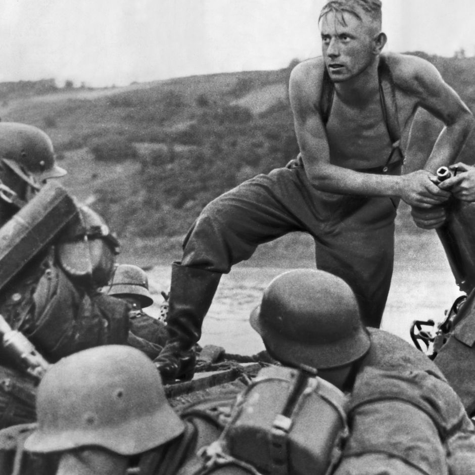

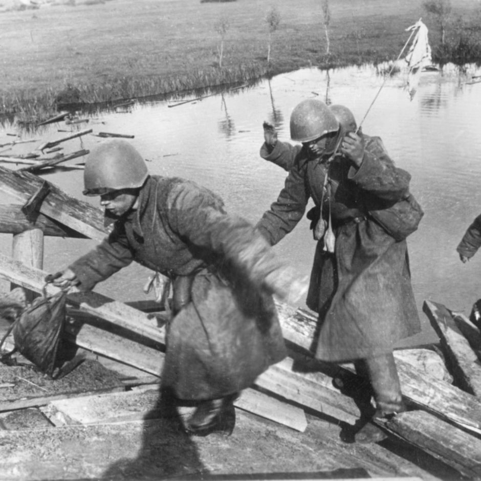

*(1) Ostfront, 1941. Soldaten auf einem Sturmboot. (2) Sowjetunion, 1941. Soldaten eines Regiments der GPU geben sich während der Kesselschlacht von Kiew gefangen.*

**Gewalt als das absolut Böse**

Nach Tolstois Geschichtstheorie wird der Ausgang einer Schlacht und des gesamten Krieges nicht durch die Pläne von Generälen und Befehlshabern, sondern durch die Entschlossenheit jedes einzelnen Soldaten bestimmt. Die russische Armee auf dem Feld von Borodino war von einem „latenten Patriotismus“ beseelt. Indem Tolstoi in dieser Formel regelmäßig das französische Wort („latente“) verwendet, unterstreicht er zum einen seine Verachtung für den im 19. Jahrhundert weit verbreiteten Sprachnationalismus, zum anderen verleiht er seinem Denken eine Art wissenschaftliche Originalität – für ihn ist es ein Phänomen, das sich naturwissenschaftlich untersuchen lässt.

Rein militärisch betrachtet, sah die Schlacht von Borodino auch eher wie eine Niederlage aus: Nach hartem Kampf zog sich die russische Armee zurück und überließ Moskau dem Feind. Aber für Tolstoi war Borodino Teil eines großen Sieges, der zur vollständigen Vertreibung der Franzosen aus Russland führte. Bezeichnenderweise endet der Schlachten-Teil des Romans mit diesem Ereignis, das für Tolstoi faktisch das Ende des Krieges bedeutet – weder der siegreiche russische Feldzug nach Paris noch die (mit dem Triumph der russisch-preußisch-österreichischen Koalition endende) Völkerschlacht von Leipzig, die größte der napoleonischen Kriege, sind für ihn von Interesse.

Tolstois Auffassung von Krieg und Gewalt, die in *Krieg und Frieden* zum Ausdruck kommt, lässt sich jedoch keineswegs auf eine Apologie des Volkskriegs reduzieren, den er als angeborenen Instinkt interpretiert. Für Tolstoi war diese Haltung natürlich, aber vormoralisch, vorchristlich – und widersprach dem persönlichen moralischen Empfinden, das dem Menschen ebenso innewohnen sollte wie die Bindung an sein Land und seine Vorfahren. Am Ende der Schlacht von Borodino, unter dem Eindruck des Todes von Zehntausenden von Männern, begann dieses Gefühl in den Seelen derer zu erwachen, die diesen schrecklichen Tag überlebt hatten:

„Erschöpft, ohne Nahrung und ohne Ruhe, begannen die Männer auf beiden Seiten denselben Zweifel zu haben, ob sie sich noch gegenseitig erschlagen sollten, und ein Zögern war auf allen Gesichtern zu sehen, und in jeder Seele wurde gleichermaßen die Frage aufgeworfen: ‚Warum, für wen soll ich töten und getötet werden? Tötet, wen ihr wollt, tut, was ihr wollt, aber ich will nicht mehr!‘ Dieser Gedanke war am Abend in allen Köpfen gleichermaßen gereift. Jeden Moment hätten alle diese Menschen entsetzt sein können über das, was sie taten, und alles stehen und liegen lassen und weglaufen können.“

Dieser Zweifel mag sich noch nicht in den Seelen der Soldaten festgesetzt haben, die ihre Pflicht taten, aber gerade sein Auftauchen ist der Schlüssel für die Möglichkeit einer moralischen Wiedergeburt zu einem Leben, das nicht auf dem tierischen Instinkt, für sich selbst einzustehen, sondern auf der Liebe und auf der bewussten Ablehnung jeglicher Gewalt beruht.

Genau diese Wende vollzieht sich in der Seele von Fürst Andrej Bolkonski, dem Helden des Romans, den Tolstoi sowohl durch Austerlitz als auch durch Borodino führt. In beiden Kämpfen wird er schwer verwundet, was ihn dazu veranlasst, sein Leben neu zu überdenken. Fürst Andrej zieht aus eigenem Antrieb in den Krieg, um zum ersten Mal aus seinem langweiligen Familienleben auszubrechen und Ruhm zu erlangen – nach dem Vorbild Napoleons, gegen den er kämpfen soll und der für ihn zugleich Idol und Vorbild ist. Eine beinahe tödliche Verletzung und der Tod seiner Frau lassen ihn an diesen eitlen Träumen verzweifeln: Er erkennt, dass der Krieg „das Schlimmste im Leben“ ist.

Seine Liebe zu Natascha Rostowa erweckt seine Lebensgeister aufs Neue – die ersten beiden Bilder in Prokofjews Oper, die die Exposition bilden, sind diesem Gefühl gewidmet. Doch die Liebe führt Bolkonski zu neuen Enttäuschungen. Seine Verlobte betrügt ihn und versucht, mit dem nichtswürdigen Anatol Kuragin zu flüchten – die Geschichte dieser Liebe, die Tolstoi den „Knoten“ des gesamten gewaltigen Romans nannte, entfaltet sich in den nächsten fünf Bildern der Oper –, bis die persönliche Peripetie der Helden von der Nachricht überschattet wird, Napoleon sei in Russland einmarschiert. Wenn Tolstois Roman *Krieg und Frieden* heißt, dann könnte die Oper aufgrund der Abfolge ihrer Teile besser *Frieden und Krieg* heißen.

Fürst Andrej schließt sich erneut der Armee an – diesmal getrieben von einem glühenden Hass auf die Angreifer und einem Gefühl der Verbundenheit mit seinem Volk und seinem Land. Aristokraten und Bauern, Soldaten und Befehlshaber, im normalen Leben durch eine unüberwindbare Barriere getrennt, verschmelzen mit Kriegsausbruch zu einem einzigen Volkskörper. Aber dieser spontane, biologische Patriotismus verschwindet in Bolkonski nach seiner neuerlichen Verwundung. Als er nach der Schlacht von Borodino im Lazarett erwacht, sieht er neben sich den verstümmelten und schluchzenden Kuragin, der ihm die Braut genommen hat und den er im Duell töten wollte. In diesem Moment empfindet er einen Impuls wahrer christlicher Liebe für den Feind:

„Durch die Tränen, die seine geschwollenen Augen füllten, erinnerte er sich jetzt an das Band, das zwischen ihm und diesem Mann bestand, der ihn trübe ansah. Fürst Andrej erinnerte sich an alles, und ein begeistertes Mitleid und eine Liebe zu diesem Mann erfüllten sein glückliches Herz (…). Mitleid, Liebe zu den Brüdern, Liebe zu denen, die uns hassen, Liebe zu den Feinden, ja, diese Liebe, die Gott auf Erden gepredigt hat (…), das war es, was mir das Leben leidtat, das war es, was mir blieb, wenn ich noch am Leben gewesen wäre. Aber jetzt ist es zu spät.“

Schon früher hatte Natascha dieselben Gedanken, ergriffen von Scham und Reue. Zu Beginn des Krieges betet sie in einer Moskauer Kirche für „diejenigen, die uns hassen“ und hört fast unmittelbar darauf ein Gebet für die Niederlage des Feindes, „aber sie konnte nicht dafür beten, dass ihre Feinde mit Füßen getreten werden, wo sie sich doch gerade noch gewünscht hatte, mehr von ihnen zu haben, sie zu lieben, für sie zu beten. Aber auch sie konnte nicht an der Richtigkeit des knienden Gebets zweifeln, das gesprochen wurde.“

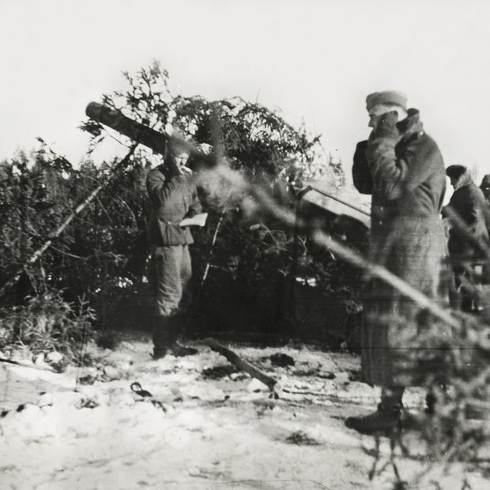

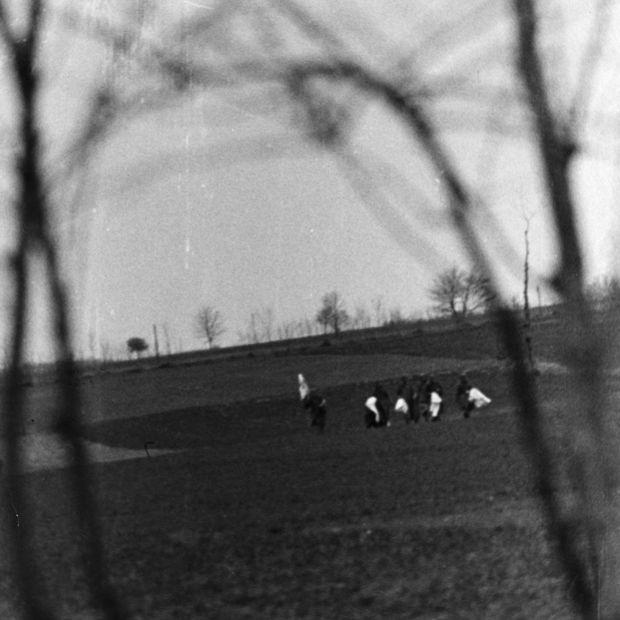

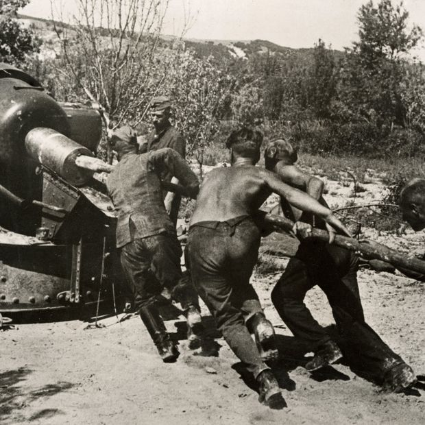

*(1) Stalingrad, 1942. Die ohrenbetäubenden Geräusche des Artilleriefeuers der deutschen Armee während der Schlacht von Stalingrad. (2) Ostfront, 1941.**Sowjetische Soldaten schwenken weisse Tücher. (3) Sevastopol, 1942. Laden eines deutschen Artilleriegeschützes an der Front von Sewastopol. ©ullstein bild*

**Auflösungen**

Bolkonski und Natascha sind dazu bestimmt, sich wieder zu treffen, und beide haben eine kurze Hoffnung auf Andrejs Genesung und neues Glück. Das letzte Zusammentreffen der Protagonisten und der Tod des Fürsten bilden den Höhepunkt der Romanhandlung, die danach auf die Auflösung zusteuert. Beim Lesen dieser Episode aus *Krieg und Frieden,* noch vor dem Einmarsch Hitlers in die UdSSR, konzipierte Prokofjew seine Oper. In ihrer endgültigen Fassung führt diese Szene die beiden sonst nur lose verbundenen Teile zusammen.

Wie Tolstoi schreibt, sahen sowohl Natascha als auch Fürst Andrejs Schwester Marja, als sie den sterbenden Fürsten betrachteten, „wie er immer tiefer sank, langsam und leise, irgendwo von ihnen hinunter, und beide wussten, dass es so sein sollte und dass es gut ist“. Tolstoi beschreibt diesen Übergang als eine Einweihung in die Quelle der christlichen Liebe. Bei Prokofjew ist es eher eine Auflösung in die göttliche Vollkommenheit des Universums. Aber es besteht kein Zweifel, dass es sich bei beiden Autoren um eine bewusste Entscheidung zwischen dem Irdischen und dem Himmlischen handelt.

Die christliche Liebe, die Fürst Andrej entdeckt, schließt das Gefühl der Verbundenheit mit seinem Heimatland, seinem Volk und seinen Nachbarn aus. Sie kennt keine Grenzen und teilt die Menschen nicht in Heimische und Fremde ein. Für Bolkonski erweist sich diese Weisheit als unvereinbar mit dem Leben. Natascha hingegen lebt weiter, findet eine neue Liebe und wird zu einer eifersüchtigen Ehefrau und fürsorglichen Mutter. Ihre irdische, biologische Bindung an die Verwandtschaft ist stärker als ihre Feindesliebe.

Viele von Tolstois Figuren schwanken auf dieser Linie zwischen dem Allgemeinen und dem Religiösen. Einen zentralen Platz im Roman nimmt Platon Karatajew ein, der Pierre Besuchow vor Verzweiflung und dem geistigen Tod in französischer Gefangenschaft rettet. Platon, von Tolstoi als ideale Verkörperung der „Volksseele“ dargestellt, ist von wahrer christlicher Liebe zu allen Lebewesen erfüllt und gleichzeitig ein alter Soldat, obwohl Tolstoi ihn nicht im Kampf zeigt und den Leser im Unklaren darüber lässt, ob Karatajew jemals Gelegenheit hatte, einen Feind zu töten.

Im letzten, achten Teil des Romans *Anna Karenina,* der etwa zehn Jahre nach *Krieg und Frieden* fertiggestellt wurde, kritisiert einer der Protagonisten, Konstantin Lewin, in dem der Leser unschwer Tolstois Alter Ego erkennt, scharf die russische Beteiligung am Krieg zur Unterstützung des serbischen Volksaufstands gegen die türkische Herrschaft. Lewin zufolge fühlten sich die russischen Bauern, die die Mehrheit der russischen Bevölkerung ausmachen, nicht mit der serbischen Sache und dem Kampf der serbischen und bulgarischen orthodoxen Slawen um nationale Befreiung verbunden. Ein großer Teil der russischen Bildungsgesellschaft war verärgert über die Haltung des berühmten Schriftstellers. Die Zeitschrift *Russischer Herold,* die zuvor sieben Teile von *Anna Karenina* veröffentlicht hatte, stellte ihr Erscheinen ein; Fjodor Dostojewski, der den Roman bis dahin bewundert hatte, sprach sich gegen Tolstoi aus. Dessen Romanfigur Lewin hingegen lehnte den Krieg als solchen nicht ab; er war der Meinung, dass er nur dann erzwungen und notwendig sein konnte, wenn er auf den unmittelbaren Gefühlen der Menschen beruhte, die ihr Land und ihre Angehörigen verteidigten, das heißt er vertrat in etwa dieselbe Position wie Fürst Andrej am Vorabend der Schlacht von Borodino.

Fast unmittelbar, nachdem Lewin wegen seiner Ansichten über den Krieg in einen Streit gerät, kommt es zu einer religiösen Bekehrung, mit deren Beschreibung der Roman endet. Wir wissen nicht, ob Lewin seine Überzeugung beibehalten hätte, dass Krieg und Mord prinzipiell irgendeine Rechtfertigung haben können, oder ob er die Wahrheit, die Fürst Andrej offenbart wurde, verstanden hätte. Tolstois religiöse Bekehrung fand etwa in denselben Monaten statt, in denen er den Umsturz bei den Lewins beschrieb – eine Wendung, die den Schriftsteller selbst zu einem festen und unnachgiebigen Pazifismus führte. Die wichtigste Veränderung, die sich in Tolstois Ansichten vollzog, bestand darin, dass ihm die Anwendung der evangelischen Lehre auf das praktische Leben nicht mehr schwierig erschien. Im Gegenteil, er kam zu dem Schluss, dass nur die Befolgung des Buchstabens und des Geistes dieser Lehre dem Leben einen Sinn gibt. Um seine Leser und vor allem sich selbst davon zu überzeugen, war es für Tolstoi wichtig zu beweisen, dass er nicht allein war. Alle seine Antikriegsreden sind gespickt mit Zitaten von Denkern und Schriftstellern, die ihm am Herzen lagen, von Plato bis Maupassant, und mit Beispielen aus dem Leben von Menschen, die zu jedem Opfer bereit waren, sich aber entschieden weigerten, den Eid zu leisten, der sie verpflichtet, ihresgleichen zu töten.

In seiner gegen Anfang der 1890er Jahre verfassten Abhandlung *Das Reich Gottes in dir* und anderen Schriften seiner letzten beiden Lebensjahrzehnte schrieb Tolstoi mehrfach über den Militärdienst als das schrecklichste Übel, das einer Gesellschaft der Gewalt und Unterdrückung zugrunde liegt. Ein Mann, der eine Militäruniform trägt, entbindet sich von der Verpflichtung, dem Diktat seines eigenen Gewissens zu folgen, da er auf Befehl von Kommandeuren tötet, die sich auf die Entscheidungen von Königen und Premierministern berufen, die ihrerseits ihre Verbrechen mit einer mythischen Staatsnotwendigkeit rechtfertigen und so die Kette der Gewalt schließen, für die niemand persönlich verantwortlich ist.

Tolstois Predigten waren für alle gleichermaßen bestimmt, und doch brannte seine Seele am meisten für die christlichen Völker; und ganz besonders, wegen der Blutsverwandtschaft, die er weiterhin empfand, für sein eigenes Volk. Tolstoi schrieb, dass Kriege, die in der Antike geführt wurden, dadurch erklärt werden konnten, dass die religiösen Ansichten der damaligen Menschen Gewalt rechtfertigten und sogar verherrlichten, aber die gegenseitige Vernichtung von Völkern, deren Religion das Blutvergießen ausdrücklich verbietet, schien ihm jeder vernünftigen Erklärung zu entbehren. Während des Russisch-Japanischen Krieges schrieb er 1904 in dem Artikel *Kommen Sie zur Vernunft:*

„Auf der einen Seite die Buddhisten, deren Gesetz das Töten nicht nur von Menschen, sondern auch von Tieren verbietet, auf der anderen Seite die Christen, die sich zum Gesetz der Brüderlichkeit und der Liebe bekennen, verfolgen einander wie wilde Tiere zu Lande und zu Wasser, um zu töten, zu foltern und auf brutalste Weise zu verstümmeln.“

Darüber hinaus konnten aus seiner Sicht die Menschen, selbst diejenigen, die sich nur formal zu den Lehren Christi bekannten, nicht umhin, die Ungeheuerlichkeit des Geschehens im Innersten zu spüren. Dieses Bewusstsein trieb sie dazu, das offensichtliche Übel mit besonderer Heftigkeit zu verteidigen und zu unterstützen. Es ist unmöglich, in seiner Charakterisierung der militaristischen Raserei, die ein ganzes Land von oben bis unten epidemisch erfasst, das Russland des Jahres 2023 nicht wiederzuerkennen:

„All diese unnatürliche, fieberhafte, hitzköpfige, wahnsinnige Aufregung, die jetzt die müßige Oberschicht der russischen Gesellschaft ergreift (…), all diese unverschämten, falschen Reden über Loyalität, Anbetung des Monarchen, über die Bereitschaft, das eigene Leben zu opfern (man sollte sagen, das Leben eines anderen, nicht das eigene), all diese Versprechen, fremde Länder mit der eigenen Brust zu verteidigen, all diese sinnlosen gegenseitigen Segnungen mit verschiedenen Bannern und hässlichen Ikonen, all diese Gebetsgottesdienste, all diese Vorbereitungen von Betttüchern und Bandagen, (…) all diese Aufmärsche, diese Forderungen nach einer Hymne, Hurra-Rufe, all diese schrecklichen, verzweifelten, unerschrockenen, weil allgemeinen Zeitungslügen, all diese Dummheit und Verwirrung, in der sich die russische Gesellschaft jetzt befindet und die sich nach und nach auf die Massen überträgt, – all das ist nur ein Zeichen des Bewusstseins des Verbrechens dieser schrecklichen Sache, die getan wird. Das unmittelbare Gefühl sagt den Menschen, dass es nicht sein sollte, was sie tun, aber als Mörder, der, nachdem er begonnen hat, das Opfer zu schneiden, nicht aufhören kann, so scheint jetzt den russischen Menschen ein unbestreitbares Argument für den Krieg zu sein, dass der Fall begonnen wurde. Der Krieg wurde begonnen, und deshalb muss er fortgesetzt werden.“

Tolstoi hatte keinen Zweifel daran, dass seine Worte auf jeden Krieg und jede Gewalt anwendbar sind, und dennoch beendete er im selben Jahr *Hadschi Murat,* in dem er mit Faszination und Liebe den wilden und rücksichtslosen Krieger beschreibt, der für seine Berge und seine Familie kämpft. Tolstois unerschütterliche antiimperialistische Haltung erreichte hier ihren Höhepunkt, aber das für sein späteres Werk charakteristische pazifistische Pathos wurde etwas gedämpft. Tolstoi stellte der Erzählung ein kurzes Vorwort voran, in dem er beschreibt, wie er, beeindruckt von der Schönheit der wilden Klette, diese mit nach Hause nehmen wollte und es mit großer Mühe schaffte, sie aus dem Boden zu ziehen. Die aus der Erde gerupfte Blume verblüht sofort. Hadschi Murat geht wie diese Klette zugrunde, als er seine Heimatberge verlässt. Die Kollision zwischen der Poesie des natürlichen biologischen Lebenstriebes einerseits und der ewigen Wahrheit des moralischen Gesetzes andererseits, die einen der semantischen Nervenstränge von *Krieg und Frieden* darstellt, bleibt für den Autor ungelöst. Dies ist wahrscheinlich nicht Tolstois Widerspruch – vielmehr ist es die Komplexität der Frage, die ihn sein ganzes Leben lang plagte.

# Krieg und Frieden (Woina i mir)

[ZUR STÜCKSEITE](https://www.staatsoper.de/stuecke/krieg-und-frieden)

# Hintergründe zum Stück

[ZUR ÜBERSICHT](https://www.staatsoper.de/inhalte-home/krieg-und-frieden-hintergruende-zum-stueck)

[interactive chart not shown]